# General Emotions – Jules

General Emotions

Emotions are the vibrant colors that paint our lives. They are complex and ever-changing, driving our thoughts, behaviors, and interactions with the world around us.

tutor

English

Author

Jules

Published

31-01-2025

Modified

31-01-2025

# 1 General emotions

When we look at our primary emotions we also feel a wide range of nuanced feelings.

| Primary.Emotions | Nuanced.Feelings |
| --- | --- |
| Happiness | Excitment |
| Sadness | Relaxation |
| Anger | Confusion |
| Fear | Disappointment |
| Surprised | Embarrassment |
|  | Pride |

**Note**

You can categorize these emotions into 3 groups:

- Baseline Emotions
- Midline Emotions
- Apex Emotions.

This classification refers to the intensity of emotions, ranging from mild to extreme.

**Note**

Emotions often exist on a spectrum, varying in strength and impact. The magnitude of emotions can be influenced by personal sensitivity, context, or external factors, causing them to fluctuate in depth and duration.

We will explore the most commonly used words to express emotions based on their intensity.

| Emotion | Mild | Moderate | High |
| --- | --- | --- | --- |
| Happiness | Happy / Cheerful | Joyful / Delighted / Elated | Thrilled / Overjoyed / Ecstatic |
| Sadness | Sad / Unhappy / Gloomy | Sorrowful / Dejected / Miserable | Heartbroken / Depressed |
| Anger | Annoyed / Frustrated | Angry / Mad / Indignant | Furious / Enraged / Irate |
| Fear | Scared / Worried | Afraid / Anxious / Alarmed | Frightened / Terrified |
| Surprised | Surprised / Startled | Astonished / Stunned | Amazed / Shocked |
| Excitment | Excited / Eager | Enthusiastic / Pumped | Stoked |
| Relaxation | Relaxed / [At ease](https://www.merriam-webster.com/dictionary/At%20ease) | Calm / Peaceful | Tranquil |
| Confusion | Confused | Puzzled / Bewildered | Perplexed |
| Disappointment | Disappointed | Letdown / Disheartened | Crestfallen |
| Embarrassment | Embarrassed | Ashamed | Humiliated / Mortified |
| Pride | Proud | Pleased / Gratified | Triumphant |

# 2 Happy & Sad

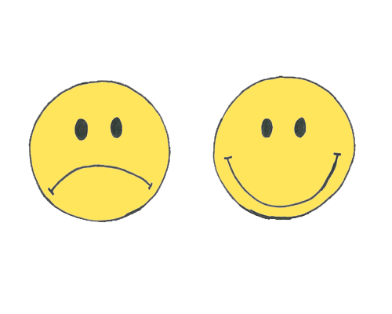

| happy | sad |
| --- | --- |
| happy | sad |
| cheerful | unhappy |
| joyful | gloomy |
| delighted | sorrowful |
| elated | dejected |
| thrilled | miserable |
| ecstatic | heartbroken |
| overjoyed | depressed |

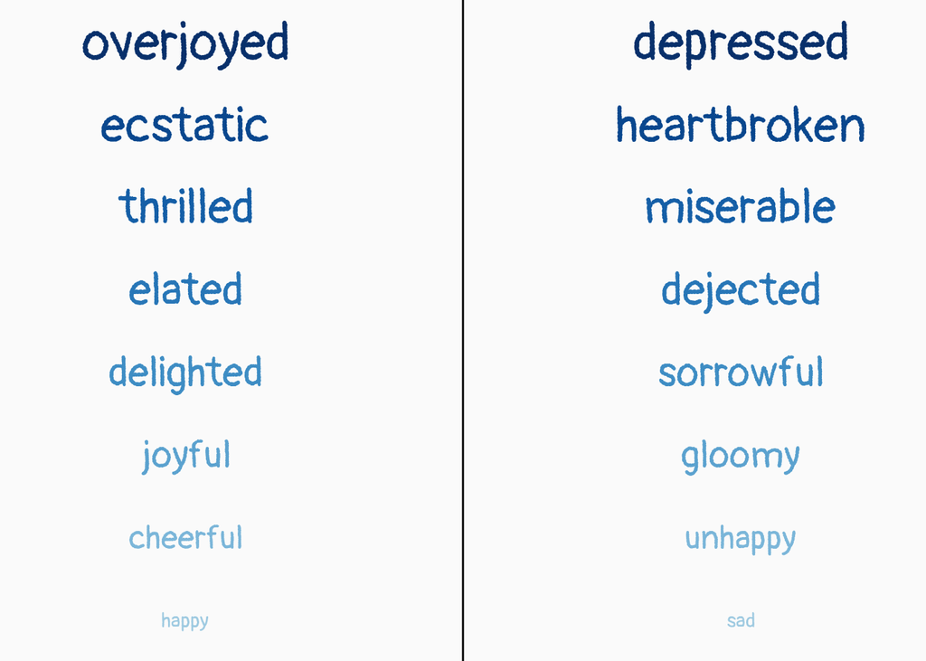

# 3 Examples

## 3.1 Happy

- “I was happy to see my friend, but I was overjoyed when they surprised me with tickets to the concert.”

**Tip**

Happy is a baseline, overjoyed is a much stronger level of happiness.

- “She felt cheerful after a good workout, but she was ecstatic when she learned she got the job she had been hoping for.”

**Tip**

Cheerful is a mild happiness, ecstatic is an intense, overwhelming joy.

- “He was delighted to receive a birthday card, but he was thrilled to win the lottery.”

**Tip**

Delighted is a pleasant level of happiness, thrilled is an exciting and exhilarating feeling.

## 3.2 Sad

- “I felt sad when it rained on my picnic, but I was heartbroken when my pet died.”

**Tip**

Sad is a general feeling of unhappiness, while heartbroken is a much deeper and more intense sadness.

- “She was unhappy about the traffic delay, but she was miserable after losing her job.”

- “He felt dejected after losing the game, but he was depressed for weeks after the breakup.”

**Tip**

Dejected is a feeling of sadness and discouragement, while depressed is a more severe and persistent state of sadness.

Back to top